# Serial tranfer model with sporulation

The chemostat model seems unhelpful to test the idea that viruses can prevent the loss of sporulation. As an alternative I will try modeling a serial transfer experiment to test if this experimental setup is more suitable.

I will be implementing the serial transfer model of:

Chaudhry, W. N., Pleška, M., Shah, N. N., Weiss, H., McCall, I. C., Meyer, J. R., … Levin, B. R. (2018). Leaky resistance and the conditions for the existence of lytic bacteriophage. PLOS Biology, 16(8), e2005971. https://doi.org/10.1371/journal.pbio.2005971

# Simple model

I will start with a model of serial transfer of a bacterium without sporulation and without phage. The model tracks changes in resources (**R**) and bacteria (**N**). According to Chandhury et al. growth dependence on resources is given as a Monod function:

$$\psi(R) = \frac {R}{k+R}$$

“*where R is the concentration (μg per mL) of the limiting resource and k is the “Monod constant,” corresponding to the concentration of the resource (μg per mL), at which the bacteria grow at a half of their maximum rate.*”

Stripping there equations from phages and mutants, and adding a mortality term (**m**) for cells I am left with

1. $$\frac{dR}{dt}=-e\cdot \psi(R)\cdot vN$$
2. $$\frac{dN}{dt}=\psi(R)\cdot v \cdot N - m\cdot N$$

where **e** is *a conversion efficacy parameter (μg per cell)* and **v** is the *maximum growth rate*.

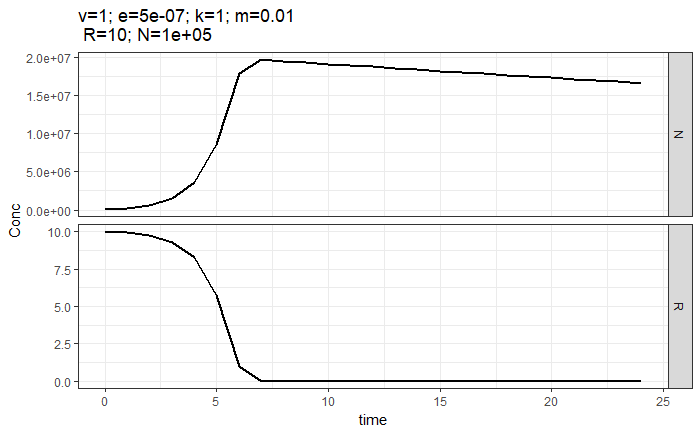

```r
#Define system of differential equations for resource and bacteria
serial <- function(t,current,params){
  with(as.list(c(params,current)), {
    #list the equations for the derivatives of each state variable
    #R is the resource (μg per mL)
    dR =  -e *(R/(R+k))*v*N

    #N are the bacteria
    dN = (R/(R+k))*v*N -m*N
    results <- c(dR, dN )
    return (list(results))
  })
}
###define parameters
# maximum growth rate
v <- 1
#conversion efficacy parameter
e <- 5e-7
#Half-saturation constant of resource uptake by bacteria
k = 1
#mortality
m=0.01
# all parameters together
params <- c (v=v,e=e, k=k,m=m)
#declare initial conditions for state variables
R_t0 <- 10
N_t0 <- 1e5
current <- c(R = R_t0 , N = N_t0)
#define the time to run model
t <- seq (0, 24, by=1)
# run the model
out <- lsoda(current, t, serial, params)
# plot(out)
#transform to long format for ggplot
out.l <- gather(as.data.frame(out), key='population', value='Conc', colnames(out)[-1])
#plot
ggplot(out.l, aes(x=time, y=Conc))+
  geom_line(size=1)+
  theme_bw()+
  scale_colour_brewer(palette='Set1')+
  ggtitle(paste(
    paste0(paste(names(params)),'=',paste(params), collapse = '; '),'\n',
    paste0(paste(names(current)),'=',paste(current), collapse = '; ')))+
  facet_grid(population~., scales = "free_y")
```

#### adding serial transfers

I will now use the events functionality of the desolve package to replenish nutrients every 24 hours

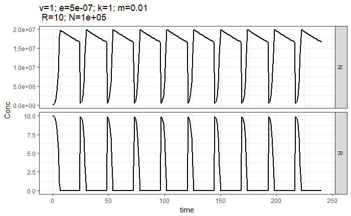

```r
# add nutrients and dilute culture at regular time intervals
event <- function(t, current, parms) {
  current['R'] <- R_t0
  current['N'] <- 0.01 * current['N']
  return(current)
}
#define the time to run model
t <- seq (0, 240, by=1)
#deine time of transfer
t.transfer <- 24
t.event <- t[t%%t.transfer==0][-1] #[-1] removes t=0
out <- lsoda(current, t, serial, params,
             events = list(func = event, time=t.event))
# transform to long format for ggplot
out.l <- gather(as.data.frame(out), key='population', value='Conc', colnames(out)[-1])
#plot
ggplot(out.l, aes(x=time, y=Conc))+
  geom_line(size=1)+
  theme_bw()+
  scale_colour_brewer(palette='Set1')+
  ggtitle(paste(
    paste0(paste(names(params)),'=',paste(params), collapse = '; '),'\n',
    paste0(paste(names(current)),'=',paste(current), collapse = '; ')))+
  facet_grid(population~., scales = "free_y")
```

```r
NA
```

#### Adding sporulation

I need to add terms that will make sporulation (**s**) and germination (**g**) dependent on **R**. I came up with the following functions:

$$s(R)=2^{-R}$$
$$g(R)= \frac {R}{R+1}$$

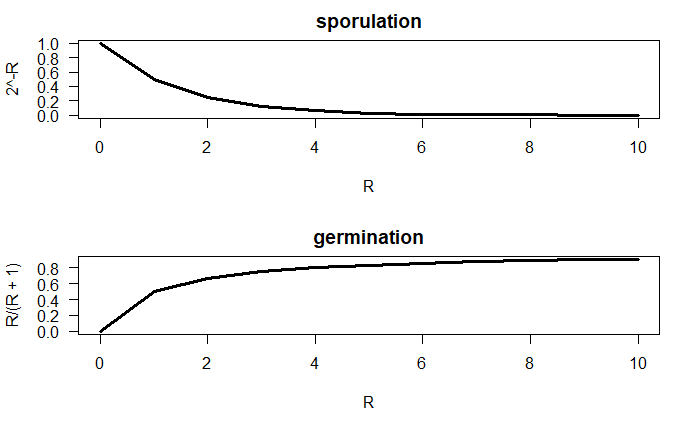

```r
R <- 0:10#seq(0,1000,by = 1)
par(mfrow=c(2, 1) )
plot(R, 2^-R, main="sporulation", type='l', lwd=3, las=1)
plot(R, R/(R+1), main="germination", type='l', lwd=3, las=1)
```

These functions are quite abrupt but they will have to do for now. I will start with a simple model without transfers.

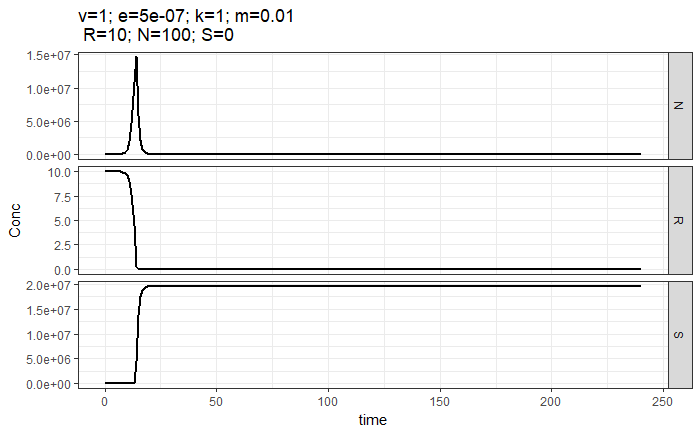

```r
#Define system of differential equations for resource and bacteria
serial <- function(t,current,params){
  with(as.list(c(params,current)), {
    #list the equations for the derivatives of each state variable
    #R is the resource (μg per mL)
    dR =  -e *(R/(R+k))*v*N

    #N are the bacteria
    dN = (R/(R+k))*v*N +(R/(R+1))*S -(2^-R)*N -m*N

    #S are the spores
    dS = (2^-R)*N -(R/(R+1))*S
    results <- c(dR, dN, dS )
    return (list(results))
  })
}
###define parameters
N_t0 <- 100
S_t0 <- 0
current <- c(R = R_t0 , N = N_t0, S=S_t0)
#define the time to run model
t <- seq (0, 240, by=1)
# run the model
out <- lsoda(current, t, serial, params)
# plot(out)
# transform to long format for ggplot
out.l <- gather(as.data.frame(out), key='population', value='Conc', colnames(out)[-1])
#plot
ggplot(out.l, aes(x=time, y=Conc))+
  geom_line(size=1)+
  theme_bw()+
  scale_colour_brewer(palette='Set1')+
  ggtitle(paste(
    paste0(paste(names(params)),'=',paste(params), collapse = '; '),'\n',
    paste0(paste(names(current)),'=',paste(current), collapse = '; ')))+
  facet_grid(population~., scales = "free_y")
```

That seems to be working. I will next add serial transfers to the sporulation model

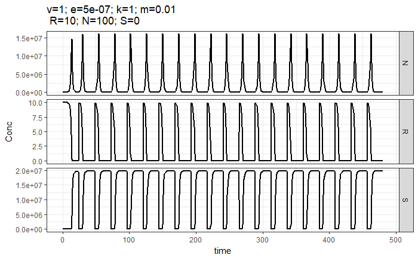

```r
# add nutrients and dilute culture at regular time intervals
event <- function(t, current, parms) {
  current['R'] <- R_t0
  current['N'] <- 0.01 * current['N']
  current['S'] <- 0.01 * current['S']
  return(current)
}
#define the time to run model
t <- seq (0, 480, by=1)
#deine time of transfer
t.transfer <-24
t.event <- t[t%%t.transfer==0][-1] #[-1] removes t=0
out <- lsoda(current, t, serial, params,
             events = list(func = event, time=t.event))
# transform to long format for ggplot
out.l <- gather(as.data.frame(out), key='population', value='Conc', colnames(out)[-1])
#plot
ggplot(out.l, aes(x=time, y=Conc))+
  geom_line(size=1)+
  theme_bw()+
  # scale_y_log10()+
  scale_colour_brewer(palette='Set1')+
  ggtitle(paste(
    paste0(paste(names(params)),'=',paste(params), collapse = '; '),'\n',
    paste0(paste(names(current)),'=',paste(current), collapse = '; ')))+
  facet_grid(population~., scales = "free_y")
```

```r
NA
```

## Will sporulation be lost in serial transfer?

To test this I will add to the system a single mutant that does not sporulate.

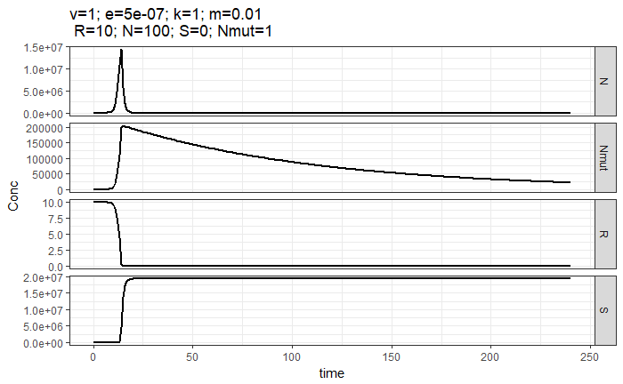

```r
#Define system of differential equations for resource and bacteria
serial <- function(t,current,params){
  with(as.list(c(params,current)), {
    #list the equations for the derivatives of each state variable
    #R is the resource (μg per mL)
    dR =  -e *(R/(R+k))*v*(N+Nmut)

    #N are the bacteria
    dN = (R/(R+k))*v*N +(R/(R+1))*S -(2^-R)*N -m*N

    #S are the spores
    dS = (2^-R)*N -(R/(R+1))*S

    #Nmut is the non-sporlator
    #N are the bacteria
    dNmut = (R/(R+k))*v*Nmut -m*Nmut
    results <- c(dR, dN, dS, dNmut )
    return (list(results))
  })
}
###define parameters
N_t0 <- 100
S_t0 <- 0
current <- c(R = R_t0 , N = N_t0, S=S_t0, Nmut=1)
#define the time to run model
t <- seq (0, 240, by=1)
# run the model
out <- lsoda(current, t, serial, params)
# plot(out)
# transform to long format for ggplot
out.l <- gather(as.data.frame(out), key='population', value='Conc', colnames(out)[-1])
#plot
ggplot(out.l, aes(x=time, y=Conc))+
  geom_line(size=1)+
  theme_bw()+
  scale_colour_brewer(palette='Set1')+
  ggtitle(paste(
    paste0(paste(names(params)),'=',paste(params), collapse = '; '),'\n',
    paste0(paste(names(current)),'=',paste(current), collapse = '; ')))+
  facet_grid(population~., scales = "free_y")
```

Without transfers the non-sporulator will eventually be lost. Next lets look at 24 hour transfers.

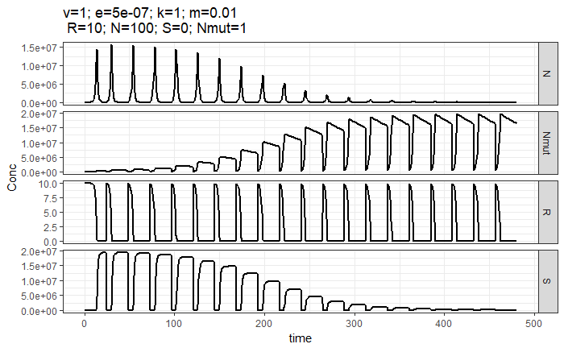

```r
# add nutrients and dilute culture at regular time intervals
event <- function(t, current, parms) {
  current['R'] <- R_t0
  current['N'] <- 0.01 * current['N']
  current['S'] <- 0.01 * current['S']
  current['Nmut'] <- 0.01 * current['Nmut']
  return(current)
}
#define the time to run model
t <- seq (0, 480, by=1)
#deine time of transfer
t.transfer <-24
t.event <- t[t%%t.transfer==0][-1] #[-1] removes t=0
out <- lsoda(current, t, serial, params,
             events = list(func = event, time=t.event))
# transform to long format for ggplot
out.l <- gather(as.data.frame(out), key='population', value='Conc', colnames(out)[-1])
#plot
ggplot(out.l, aes(x=time, y=Conc))+
  geom_line(size=1)+
  theme_bw()+
  # scale_y_log10()+
  scale_colour_brewer(palette='Set1')+
  ggtitle(paste(
    paste0(paste(names(params)),'=',paste(params), collapse = '; '),'\n',
    paste0(paste(names(current)),'=',paste(current), collapse = '; ')))+
  facet_grid(population~., scales = "free_y")
```

```r
NA
```

Under this transfer regime the sporulator is out competed. How about if we transfer every 10 days?

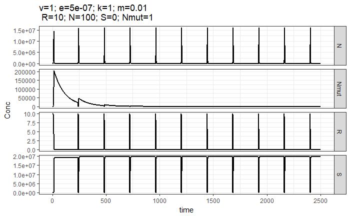

```r
#define the time to run model
t <- seq (0, 2500, by=1)
#deine time of transfer
t.transfer <-240
t.event <- t[t%%t.transfer==0][-1] #[-1] removes t=0
out <- lsoda(current, t, serial, params,
             events = list(func = event, time=t.event))
# transform to long format for ggplot
out.l <- gather(as.data.frame(out), key='population', value='Conc', colnames(out)[-1])
#plot
ggplot(out.l, aes(x=time, y=Conc))+
  geom_line(size=1)+
  theme_bw()+
  # scale_y_log10()+
  scale_colour_brewer(palette='Set1')+
  ggtitle(paste(
    paste0(paste(names(params)),'=',paste(params), collapse = '; '),'\n',
    paste0(paste(names(current)),'=',paste(current), collapse = '; ')))+
  facet_grid(population~., scales = "free_y")
```

```r
NA
```

This enables the sporulator to out-compete the invader. Now the model captures the expected behavior: sporulation is maintained when resource supply is infrequent. Lets see if the virus can help maintain sporulation when the resource supply does not favor it (1 day transfers).

#### Adding a virus

Using functions of Chaudury paper, but adding a mortality rate also for the virus. At first its the same mortality as the active cells.(m=0.01)

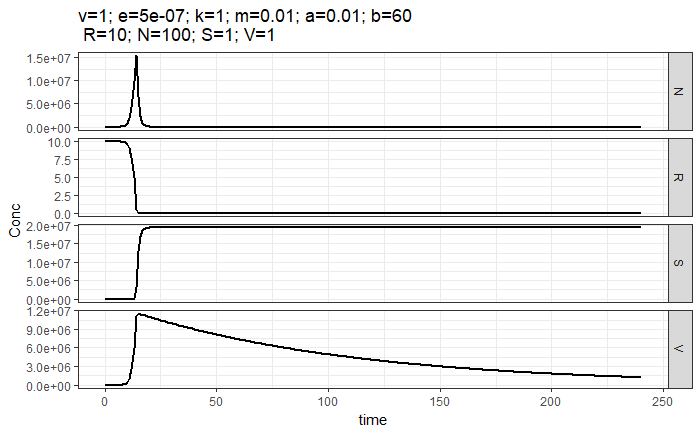

```r
serial <- function(t,current,params){
  with(as.list(c(params,current)), {
    #list the equations for the derivatives of each state variable
    #R is the resource (μg per mL)
    dR =  -e *(R/(R+k))*v*N

    #N are the bacteria
    dN = (R/(R+k))*v*N +(R/(R+1))*S -(2^-R)*N -a*(R/(R+k))*v*N -m*N

    #S are the spores
    dS = (2^-R)*N -(R/(R+1))*S

    #V are the viruses
    dV = a*(R/(R+k))*v*N*(b-1)-m*V
    results <- c(dR, dN, dS, dV )
    return (list(results))
  })
}
###define parameters
#viral growth rate
a <- .01
#burst size
b <- 60
# all parameters together
params <- c (v=v,e=e, k=k,m=m, a=a, b=b)
V_t0 <- 1
S_t0 <- 1
current <- c(R = R_t0 , N = N_t0, S=S_t0, V=V_t0)
#define the time to run model
t <- seq (0, 240, by=1)
# run the model
out <- lsoda(current, t, serial, params)
# plot(out)
# transform to long format for ggplot
out.l <- gather(as.data.frame(out), key='population', value='Conc', colnames(out)[-1])
#plot
ggplot(out.l, aes(x=time, y=Conc))+
  geom_line(size=1)+
  theme_bw()+
  scale_colour_brewer(palette='Set1')+
  # scale_x_log10()+
  ggtitle(paste(
    paste0(paste(names(params)),'=',paste(params), collapse = '; '),'\n',
    paste0(paste(names(current)),'=',paste(current), collapse = '; ')))+
  facet_grid(population~., scales = "free_y")
```

Works reasonably well. Though that ‘a’ parameter is a bit unclear. I will next add transfers to this model.

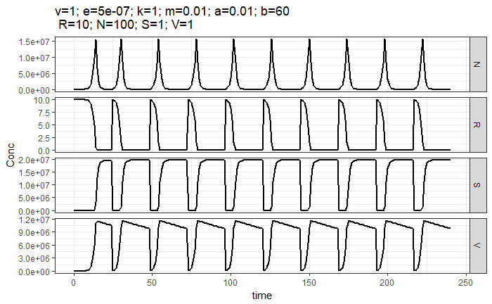

```r
# add nutrients and dilute culture at regular time intervals
event <- function(t, current, parms) {
  current['R'] <- R_t0
  current['N'] <- 0.01 * current['N']
  current['S'] <- 0.01 * current['S']
  current['V'] <- 0.01 * current['V']
  return(current)
}
#define the time to run model
t <- seq (0, 240, by=1)
#deine time of transfer
t.transfer <-24
t.event <- t[t%%t.transfer==0][-1] #[-1] removes t=0
out <- lsoda(current, t, serial, params,
             events = list(func = event, time=t.event))
# transform to long format for ggplot
out.l <- gather(as.data.frame(out), key='population', value='Conc', colnames(out)[-1])
#plot
ggplot(out.l, aes(x=time, y=Conc))+
  geom_line(size=1)+
  theme_bw()+
  # scale_y_log10()+
  scale_colour_brewer(palette='Set1')+
  ggtitle(paste(
    paste0(paste(names(params)),'=',paste(params), collapse = '; '),'\n',
    paste0(paste(names(current)),'=',paste(current), collapse = '; ')))+
  facet_grid(population~., scales = "free_y")
```

```r
NA
```

Now adding a non-sporulating invader. Viruses can infect active cells of both types but not the spores.

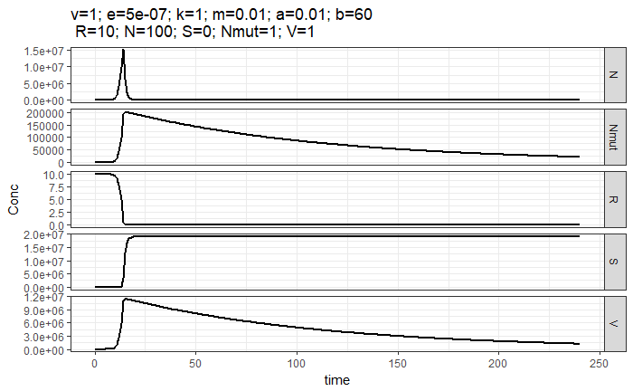

```r
#Define system of differential equations for resource and bacteria
serial <- function(t,current,params){
  with(as.list(c(params,current)), {
    #list the equations for the derivatives of each state variable
    #R is the resource (μg per mL)
    dR =  -e *(R/(R+k))*v*(N+Nmut)

    #N are the bacteria
    dN = (R/(R+k))*v*N +(R/(R+1))*S -(2^-R)*N -a*(R/(R+k))*v*N  -m*N

    #S are the spores
    dS = (2^-R)*N -(R/(R+1))*S

    #Nmut is the non-sporlator
    dNmut = (R/(R+k))*v*Nmut -a*(R/(R+k))*v*Nmut  -m*Nmut

    #V are the viruses
    dV = a*(R/(R+k))*v*(N+Nmut)*(b-1)-m*V
    results <- c(dR, dN, dS, dNmut, dV )
    return (list(results))
  })
}
###define starting values
N_t0 <- 100
S_t0 <- 0
current <- c(R = R_t0 , N = N_t0, S=S_t0, Nmut=1, V=1)
#define the time to run model
t <- seq (0, 240, by=1)
# run the model
out <- lsoda(current, t, serial, params)
# plot(out)
# transform to long format for ggplot
out.l <- gather(as.data.frame(out), key='population', value='Conc', colnames(out)[-1])
#plot
ggplot(out.l, aes(x=time, y=Conc))+
  geom_line(size=1)+
  theme_bw()+
  scale_colour_brewer(palette='Set1')+
  ggtitle(paste(
    paste0(paste(names(params)),'=',paste(params), collapse = '; '),'\n',
    paste0(paste(names(current)),'=',paste(current), collapse = '; ')))+
  facet_grid(population~., scales = "free_y")
```

Without transfers the non-sporulator will eventually be lost. Next lets look at 24 hour transfers.

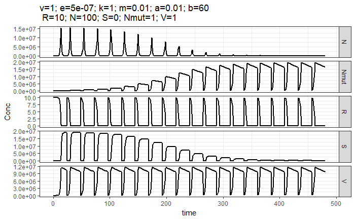

```r
# add nutrients and dilute culture at regular time intervals
event <- function(t, current, parms) {
  current['R'] <- R_t0
  current['N'] <- 0.01 * current['N']
  current['S'] <- 0.01 * current['S']
  current['Nmut'] <- 0.01 * current['Nmut']
  current['V'] <- 0.01 * current['V']
  return(current)
}
#define the time to run model
t <- seq (0, 480, by=1)
#deine time of transfer
t.transfer <-24
t.event <- t[t%%t.transfer==0][-1] #[-1] removes t=0
out <- lsoda(current, t, serial, params,
             events = list(func = event, time=t.event))
# transform to long format for ggplot
out.l <- gather(as.data.frame(out), key='population', value='Conc', colnames(out)[-1])
#plot
ggplot(out.l, aes(x=time, y=Conc))+
  geom_line(size=1)+
  theme_bw()+
  # scale_y_log10()+
  scale_colour_brewer(palette='Set1')+
  ggtitle(paste(
    paste0(paste(names(params)),'=',paste(params), collapse = '; '),'\n',
    paste0(paste(names(current)),'=',paste(current), collapse = '; ')))+
  facet_grid(population~., scales = "free_y")
```

```r
NA
```

The sporulator is out competed! Lets look at that plot in log scale. The reason I do this is to make sure the the mutant is not surviving in infinitesimal numbers.

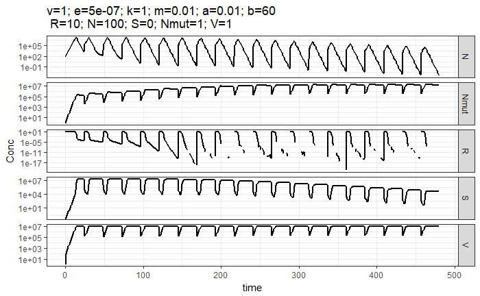

Except for the resources everything seems to fluctuating in reasonable numbers.

## Critical length of transfer

So far I have seen that in the absence of a virus the sporulator wins in 10-day transfers but loses in 1 day transfers. I now want to find the time length of transfers at which the system shifts from one outcome to the other. I will then ask if that transition point is influenced by the addition of the virus.

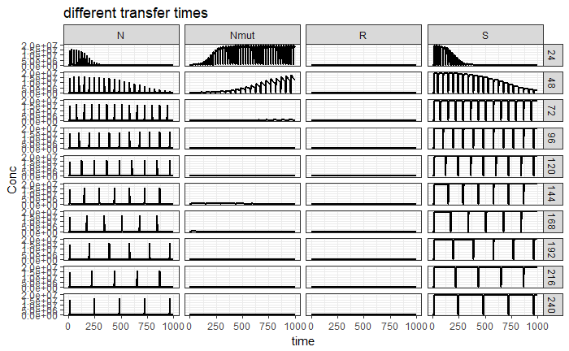

It looks like 3 days (72hrs) is the minimal transfer length that favors the sporulator. However the mutant does seem to e slightly rising towards the end. Lets look what happens to the mutant.

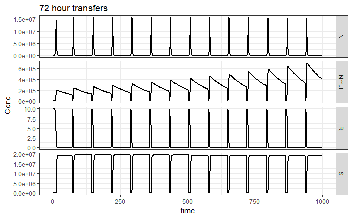

It appears that at 3 day transfers the mutant will win after all, it will just take a longer time than the model was run here. Lets run it longer.

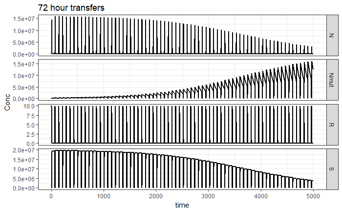

```r
#define the time to run model
t <- seq (0, 5000, by=1)
#deine time of transfer
t.transfer <-72
t.event <- t[t%%t.transfer==0][-1] #[-1] removes t=0
#run model
out <- lsoda(current, t, serial, params,
             events = list(func = event, time=t.event))
# transform to long format for ggplot
out.l <- gather(as.data.frame(out), key='population', value='Conc', colnames(out)[-1])
ggplot(out.l, aes(x=time, y=Conc))+
  geom_line(size=1)+
  theme_bw()+
  # scale_y_log10()+
  scale_colour_brewer(palette='Set1')+
  ggtitle("72 hour transfers")+
  facet_grid(population~., scales = "free_y")
```

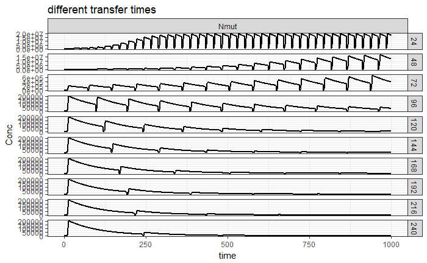

It can be seen that at the next transfer time (96hours) the mutant numbers decrease with every transfer. Lets refine that with respect to time

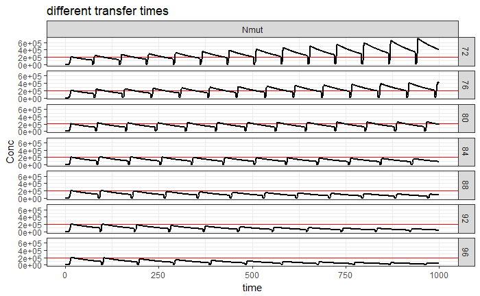

The red line in all the plots above is at the same value (value of peak before first transfer) and is meant to aid see the overall pattern. The transition from Nmut increase to decrease occurs between transfer times of 80 and 84 hours.

#### Is this pattern altered by the addition of viruses?

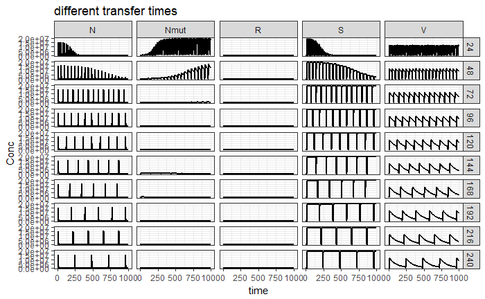

```r
#Define system of differential equations for resource and bacteria
serial <- function(t,current,params){
  with(as.list(c(params,current)), {
    #list the equations for the derivatives of each state variable
    #R is the resource (μg per mL)
    dR =  -e *(R/(R+k))*v*(N+Nmut)

    #N are the bacteria
    dN = (R/(R+k))*v*N +(R/(R+1))*S -(2^-R)*N -a*(R/(R+k))*v*N  -m*N

    #S are the spores
    dS = (2^-R)*N -(R/(R+1))*S

    #Nmut is the non-sporulator
    dNmut = (R/(R+k))*v*Nmut -a*(R/(R+k))*v*Nmut  -m*Nmut

    #V are the viruses
    dV = a*(R/(R+k))*v*(N+Nmut)*(b-1)-m*V
    results <- c(dR, dN, dS, dNmut, dV )
    return (list(results))
  })
}
###define parameters
#viral growth rate
a <- .01
#burst size
b <- 60
# all parameters together
params <- c (v=v,e=e, k=k,m=m, a=a, b=b)
###define parameters
N_t0 <- 100
S_t0 <- 0
current <- c(R = R_t0 , N = N_t0, S=S_t0, Nmut=1, V=1)
# add nutrients and dilute culture at regular time intervals
event <- function(t, current, parms) {
  current['R'] <- R_t0
  current['N'] <- 0.01 * current['N']
  current['S'] <- 0.01 * current['S']
  current['Nmut'] <- 0.01 * current['Nmut']
  current['V'] <- 0.01 * current['V']
  return(current)
}
#define the time to run model
t <- seq (0, 1000, by=1)
#start empty data frame to store results
out.all <- data.frame( time=NA, population=NA, Conc=NA, t.transfer=NA)[FALSE,]
times <- seq(24,240,24)
for (i in times){
  #deine time of transfer
  t.transfer <-i
  t.event <- t[t%%t.transfer==0][-1] #[-1] removes t=0

  #run model
  out <- lsoda(current, t, serial, params,
               events = list(func = event, time=t.event))

  # transform to long format for ggplot
  out.l <- gather(as.data.frame(out), key='population', value='Conc', colnames(out)[-1])
  out.l$t.transfer <- t.transfer
  #append results to data frame
  out.all <- rbind(out.all,out.l)
}
#plot
ggplot(out.all, aes(x=time, y=Conc))+
  geom_line(size=1)+
  theme_bw()+
  # scale_y_log10()+
  scale_colour_brewer(palette='Set1')+
  ggtitle("different transfer times")+
  facet_grid(t.transfer~population, scales = "free_y")
```

It looks quite similar to the no virus case. Let’s look at Nmut only:

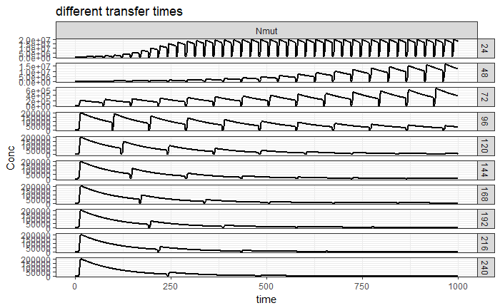

Indeed, this is the same as without the virus. Lets look at the refined transfer time resolution

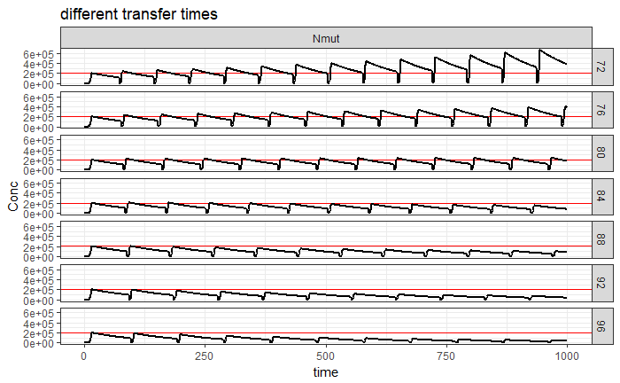

```r
#define the time to run model
t <- seq (0, 1000, by=1)
#start empty data frame to store results
out.all <- data.frame( time=NA, population=NA, Conc=NA, t.transfer=NA)[FALSE,]
times <- seq(72,96,4)
for (i in times){
  #deine time of transfer
  t.transfer <-i
  t.event <- t[t%%t.transfer==0][-1] #[-1] removes t=0

  #run model
  out <- lsoda(current, t, serial, params,
               events = list(func = event, time=t.event))

  # transform to long format for ggplot
  out.l <- gather(as.data.frame(out), key='population', value='Conc', colnames(out)[-1])
  out.l$t.transfer <- t.transfer
  #append results to data frame
  out.all <- rbind(out.all,out.l)
}
mx <- max(out.all$Conc[out.all$t.transfer==96 & out.all$population=='Nmut'])
#plot
ggplot(filter(out.all, population=='Nmut'), aes(x=time, y=Conc))+
  geom_hline(aes(yintercept = mx), color='red')+
  geom_line(size=1)+
  theme_bw()+
  scale_colour_brewer(palette='Set1')+
  ggtitle("different transfer times")+
  facet_grid(t.transfer~population)
```

Even at this finer resolution I don’t see any influence of the virus on the outcome of invasion of sporulators by non-sporulating mutant.

What if we increase the selective pressure of viral infection? I will dial up the burst size 1000-fold to 60,000.

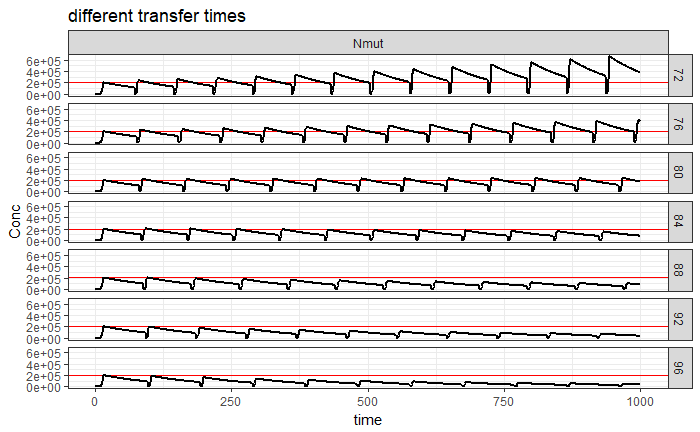

```r
# all parameters together
params <- c (v=v,e=e, k=k,m=m, a=a, b=1000*b)
#define the time to run model
t <- seq (0, 1000, by=1)
#start empty data frame to store results
out.all <- data.frame( time=NA, population=NA, Conc=NA, t.transfer=NA)[FALSE,]
times <- seq(72,96,4)
for (i in times){
  #deine time of transfer
  t.transfer <-i
  t.event <- t[t%%t.transfer==0][-1] #[-1] removes t=0

  #run model
  out <- lsoda(current, t, serial, params,
               events = list(func = event, time=t.event))

  # transform to long format for ggplot
  out.l <- gather(as.data.frame(out), key='population', value='Conc', colnames(out)[-1])
  out.l$t.transfer <- t.transfer
  #append results to data frame
  out.all <- rbind(out.all,out.l)
}
mx <- max(out.all$Conc[out.all$t.transfer==96 & out.all$population=='Nmut'])
#plot
ggplot(filter(out.all, population=='Nmut'), aes(x=time, y=Conc))+
  geom_hline(aes(yintercept = mx), color='red')+
  geom_line(size=1)+
  theme_bw()+
  scale_colour_brewer(palette='Set1')+
  ggtitle("different transfer times")+
  facet_grid(t.transfer~population)
```

Still the same.

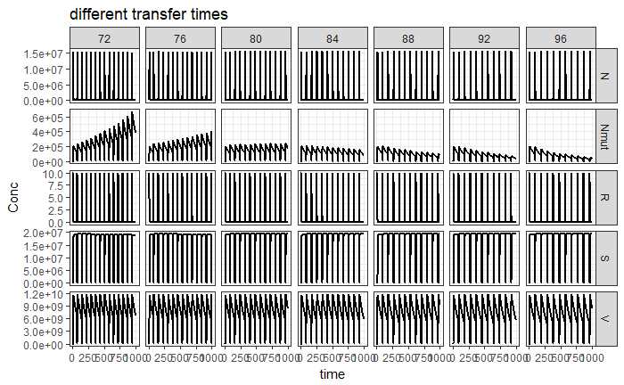

## Conclusion

The presence of viruses has no impact on the out come of invasion of non-sporulator mutant into a population of sporulators. Spores do not offer a refuge.